# 03_Figures

Sophie Buysse

2026-05-19

# description

# Prep code

load packages

```r
library(dplyr)
```

```r
library(ggplot2)
library(tidyr)
library(ggpubr)
#remove.packages("ragg")

# functions used for growth curves
std_mean <- function(x){
  sd(x, na.rm = TRUE)/sqrt(length(x))
}

# Confidence interval multiplier for standard error
conf_int <- function(x, conf.interval = 0.95){
  ciMult <- qt((1+conf.interval)/2, length(x)-1)
  ci <- std_mean(x) * ciMult
  return(ci)
}
```

Set theme for plots

```r
windowsFonts(Times=windowsFont("TT Times New Roman"))
theme_set(theme_classic())
theme_update(legend.title = element_text(family = "Times", color = "black", size = 14),
    legend.text = element_text(family = "Times", color = "black", size = 14),
    axis.title = element_text(family = "Times", color = "black", size = 14),
    axis.text = element_text(family = "Times", color = "black", size = 14),
    axis.line = element_line(colour = 'black', linewidth = 1),
    axis.ticks = element_line(color = 'black', linewidth = 1),
    axis.ticks.length=unit(.15, "cm"),
    legend.spacing.y = unit(0.03, "cm"),
    panel.border = element_blank(),
    panel.grid.major.x = element_blank(),
    panel.grid.minor.x = element_blank(),
    plot.margin = margin(t=1, r=0.075, b=0.075, l=0.05, unit = "in")
    )
```

# read in data

Read in the data needed for all plotting.

```r
# 2021
Dat_2021 <- read.csv("data/CleanData_2021.csv")
# set factors
Dat_2021 <- Dat_2021 %>% dplyr::mutate(
  Population = as.factor(Population),
  Line = as.factor(Line),
  Treatment = as.factor(Treatment),
  Soil.Mix.Batch.Number.x = as.factor(Soil.Mix.Batch.Number.x),
  BranchStructure = as.factor(BranchStructure),
  DoneFlwr = as.factor(DoneFlwr)
)

# for plotting
load("data/ModelMeans_2021.robj")
load("data/SampleSizes_2021.robj")


# 2022
Dat_2022 <- read.csv("data/CleanData_2022.csv")
# make some things factors
Dat_2022$Treatment <- as.factor(Dat_2022$Treatment)
Dat_2022$Population <- as.factor(Dat_2022$Population)
Dat_2022$PotID <- as.factor(Dat_2022$PotID)
Dat_2022$Flat <- as.factor(Dat_2022$Flat)
Dat_2022$Chamber <- as.factor(Dat_2022$Chamber)
Dat_2022$Transplanted <- as.factor(Dat_2022$Transplanted)

load("data/ModelMeans_2022.robj")
load("data/SampleSizes_2022.robj")
```

# phenology

Graphs showing general phenology trends. The goal of these is a quick comparison.

2021

2022 - note: plants that died or were transplanted are not shown here because they may have an emergence date and no bolting date (if died) or a bolting date and no emergence date (if transplanted)

# 2021 only

Reaction norms to make here:  
- DaysToBolting(b/c exp differences)  
- DaysBoltingToFlwr  
- LeafNum_duringvern (if included)  
- LeafNum_Oct4 (if included)  
- RosetteLeafNum_harvest  
- RosetteDry_harvest  
- DryReproG  
- Repro_to_Ros  
- LatBranches  
- PrimaryStalks  
- Height_cm  
- IJ_BasiaCounts  
- AG_biomass (Ros+Repro)  
- fitness  
- AvgSeedWt  
- AvgSeedNum

## Phenology

Days Emergence to bolting

DaysBoltingToFlwr

Days Emergence to Flower

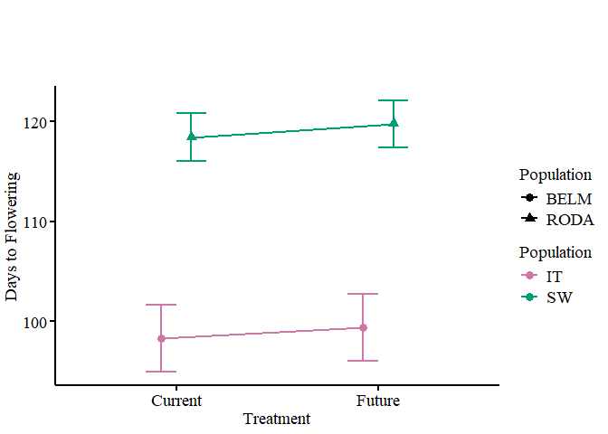

## Leaf Number

LeafNum_duringvern

LeafNum_Oct4

RosetteLeafNum_harvest

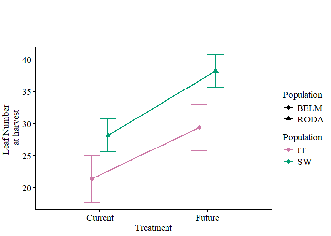

Create an extra figure to look at growth curves during this time.

```r
# format a dataframe
tmp_mean_21 <- Dat_2021 %>%
  dplyr::group_by(Population) %>%
  dplyr::group_by(Treatment, .add = TRUE) %>%
  summarize(across(.col = c(LeafNum_.07222021, LeafNum_08262021, RosetteLeafNum_10042021, RosetteLeafNum), .fns = list(mean = ~mean(.x, na.rm = TRUE, .group = "keep"))))
# pivot
tmp_mean_21 <- pivot_longer(tmp_mean_21, cols = !(c(Population, Treatment)), names_to = "Time", values_to = "mean")
tmp_mean_21$Time <- factor(rep(c("Week5", "Week10", "Week14", "Harvest"), times = 4), levels = c("Week5", "Week10", "Week14", "Harvest"))

tmp_ci_21 <- Dat_2021 %>%
  dplyr::group_by(Population) %>%
  dplyr::group_by(Treatment, .add = TRUE) %>%
  summarize(across(.col = c(LeafNum_.07222021, LeafNum_08262021, RosetteLeafNum_10042021, RosetteLeafNum), .fns = list(ci_95 = ~conf_int(.x))))

# pivot
tmp_ci_21 <- pivot_longer(tmp_ci_21, cols = !(c(Population, Treatment)), names_to = "Time", values_to = "ci")
tmp_ci_21$Time <- factor(rep(c("Week5", "Week10", "Week14", "Harvest"), times = 4), levels = c("Week5", "Week10", "Week14", "Harvest"))

forplot3_2021 <- merge(tmp_mean_21, tmp_ci_21)

# plot
ggplot(data = forplot3_2021, aes(x = Time, y = mean)) +
  geom_point(aes(col=Population, shape = Population), size = 3, show.legend = TRUE) +
  #geom_errorbar(aes(ymin=mean-ci, ymax = mean + ci, col = Population), width = 0.1, size = 0.8, show.legend = TRUE)+
  geom_line(aes(group = Treatment:Population, col = Population, linetype = Treatment), size = 1)+
  labs(y="Leaf Number",
      x="Treatment")+
  scale_color_manual(name = "Population",
                     labels = c("IT", "SW"),
                     values = c("#CC79A7", "#009E73"))+
  scale_x_discrete(expand = c(0.2,0))
```

[output not shown]

## Plant Structure

RosetteDry_harvest

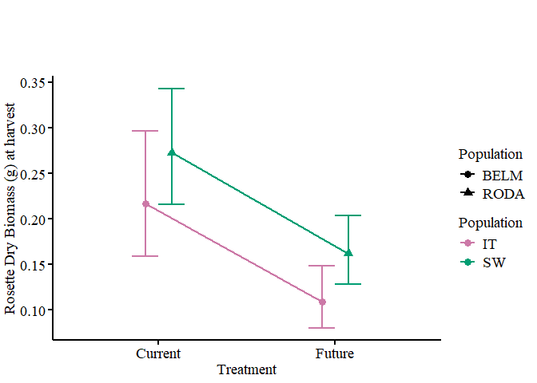

DryReproG

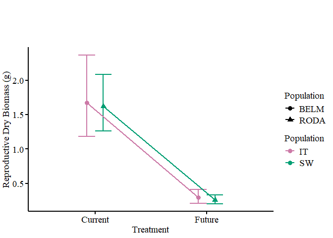

AG_biomass (Ros+Repro)

Repro_to_Ros

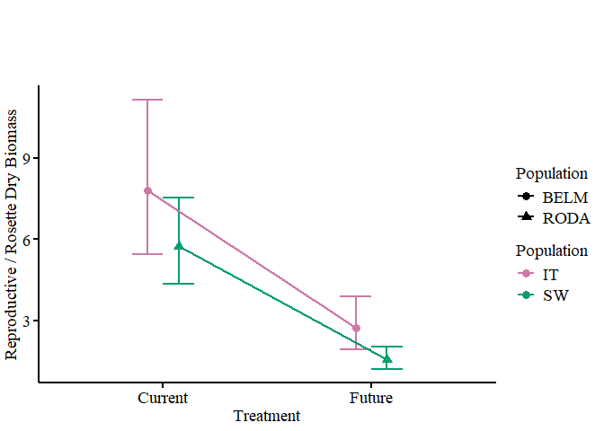

LatBranches

PrimaryStalks - how many stalks are coming out of the top of the rosette?

Height_cm (of main stalk)

## fitness + fitness related

FruitCount - BL

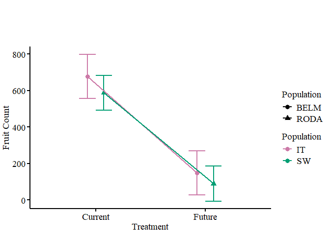

AvgSeedWt

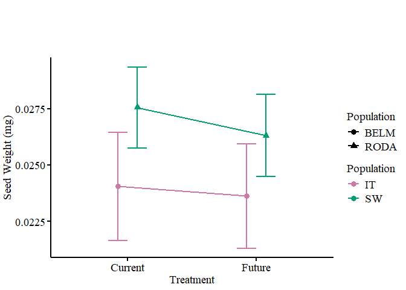

AvgSeedNum

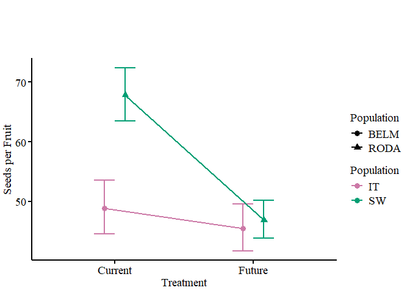

fitness - avg seed num/fruit * fruit num

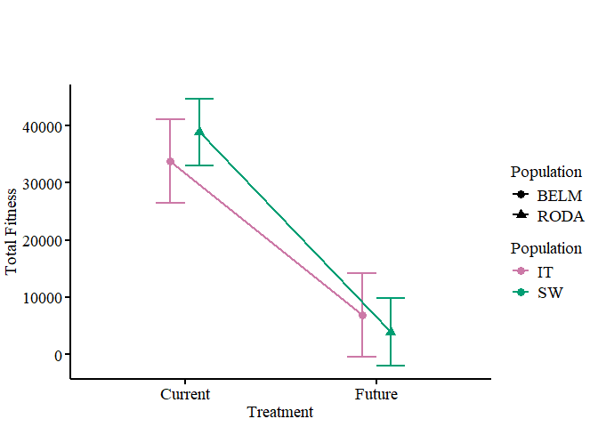

# 2022 only

Graphs to make here:  
- LeafNum_Jun6 (if included)  
- LeafNum_Jun13 (if included)  
- LeafNum_bolt  
- AG_Dry_bolt  
- BG_Dry_bolt  
- Root_to_Shoot  
- Stomata_density

Note: skipping days from emergence to bolting because most of that time is the same treatment.

## Leaf Number

LeafNum_Jun6

LeafNum_Jun13

LeafNum_bolt

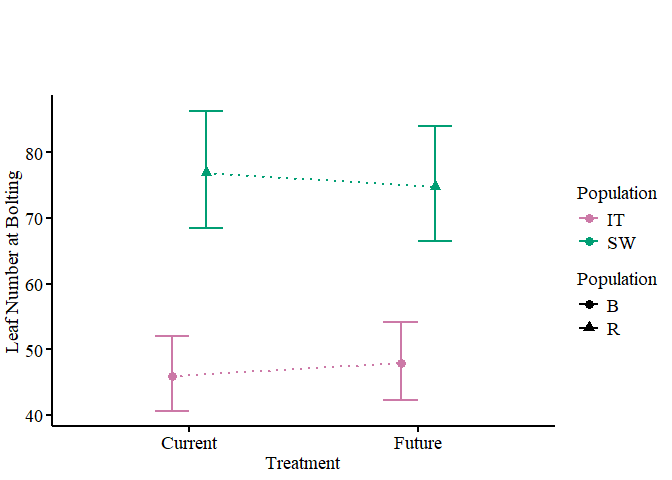

Create an extra figure to look at growth curves during this time.

```r
# format a dataframe
tmp_mean <- Dat_2022 %>%
  dplyr::group_by(Population) %>%
  dplyr::group_by(Treatment, .add = TRUE) %>%
  summarize(across(.col = c(LeafNumber_PreVern:LeafNumber_Jun13, LeafNumber_Total), .fns = list(mean = ~mean(.x, na.rm = TRUE, .group = "keep"))))
# pivot
tmp_mean <- pivot_longer(tmp_mean, cols = !(c(Population, Treatment)), names_to = "Time", values_to = "mean")
tmp_mean$Time <- factor(rep(c("Week5", "Week9", "Week10", "Bolting"), times = 4), levels = c("Week5", "Week9", "Week10", "Bolting"))

tmp_ci <- Dat_2022 %>%
  dplyr::group_by(Population) %>%
  dplyr::group_by(Treatment, .add = TRUE) %>%
  summarize(across(.col = c(LeafNumber_PreVern:LeafNumber_Jun13, LeafNumber_Total), .fns = list(ci_95 = ~conf_int(.x))))

# pivot
tmp_ci <- pivot_longer(tmp_ci, cols = !(c(Population, Treatment)), names_to = "Time", values_to = "ci")
tmp_ci$Time <- factor(rep(c("Week5", "Week9", "Week10", "Bolting"), times = 4), levels = c("Week5", "Week9", "Week10", "Bolting"))

forplot3_2022 <- merge(tmp_mean, tmp_ci)

# plot
ggplot(data = forplot3_2022, aes(x = Time, y = mean)) +
  geom_point(aes(col=Population, shape = Population), size = 2, show.legend = TRUE) +
  #geom_errorbar(aes(ymin=mean-ci, ymax = mean + ci, col = Population), width = 0.1, size = 0.8, show.legend = TRUE)+
  geom_line(aes(group = Treatment:Population, col = Population, linetype = Treatment), size = 1)+
  labs(y="Leaf Number",
      x="Treatment")+
  scale_color_manual(name = "Population",
                     labels = c("IT", "SW"),
                     values = c("#CC79A7", "#009E73"))+
  scale_x_discrete(expand = c(0.2,0))
```

[output not shown]

## Biomass

AG_Dry_bolt

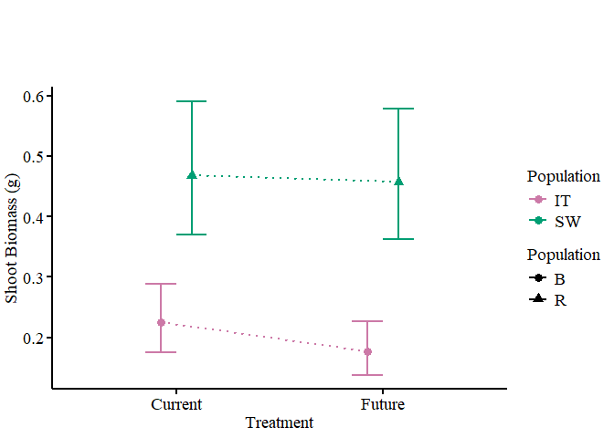

```
## [1] -0.2225461
```

```
## [1] -0.02154174
```

BG_Dry_bolt

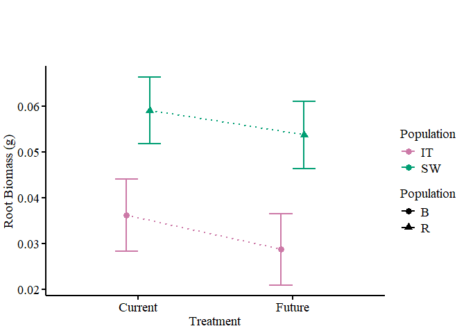

```
## [1] -0.2170143
```

```
## [1] -0.09097503
```

Root_to_Shoot

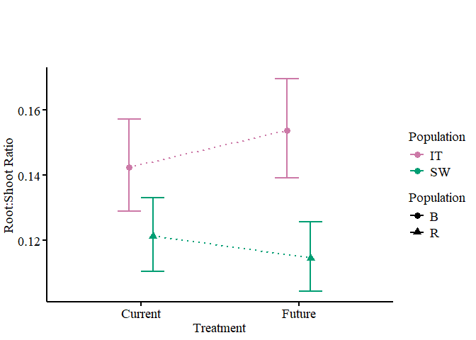

Total Biomass

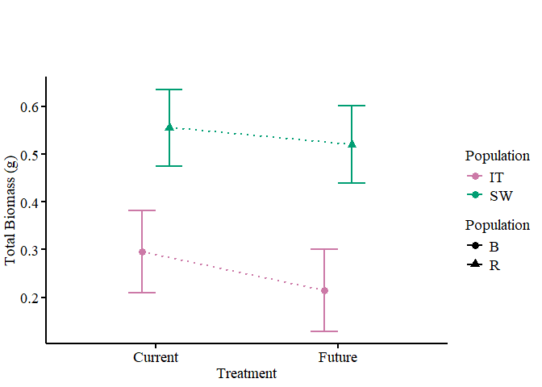

## Stomata

Stomata Density

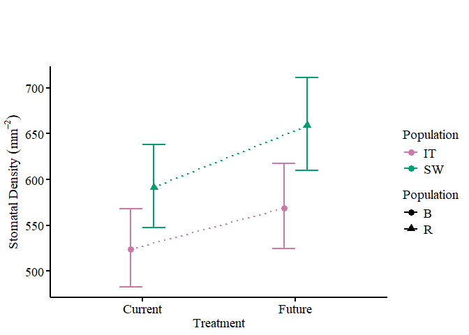

# both

Reaction Norms to create here:  
- Emergence  
- EmergenceToBolting  
- FreshWt  
- HydWt  
- DryWt  
- LeafArea  
- LeafPerimeter  
- SLA  
- LDMC  
- RWC  
- LeafNum_4weeks

```r
# subset 2021 dataset
both_exp <- c("fresh_means_21", "sat_means_21", "dry_means_21", "area_means_21","SLA_means_21", "LDMC_means_21", "RWC_means_21")
both_2021 <- Means_2021[both_exp]
both_2021 <- lapply(both_2021, cbind, Exp = as.factor(c("2021")))

# subset 2022 dataset
both_exp2 <- c("fresh_means_22", "hyd_means_22", "dry_means_22", "area_means_22", "sla_means_22", "ldmc_means_22", "rwc_means_22")
both_2022 <- Means_2022[both_exp2]
# change B and R to Belm and Roda
for (i in 1:length(both_2022)){
  both_2022[[i]]$Population <- as.character(both_2022[[i]]$Population)
  both_2022[[i]][both_2022[[i]]$Population == "B", "Population"] <- "BELM"
  both_2022[[i]][both_2022[[i]]$Population == "R", "Population"] <- "RODA"
  both_2022[[i]]$Population <- as.factor(both_2022[[i]]$Population)
}
both_2022 <- lapply(both_2022, cbind, Exp = as.factor(c("2022")))


# merge - do this within a loop
mylist.names <- c("fresh", "hyd", "dry", "area", "sla", "ldmc", "rwc")
both_dfs <-  vector("list", length(mylist.names))
names(both_dfs) <- mylist.names

for (i in 1:length(both_dfs)){
  both_dfs[[i]] <- bind_rows(both_2021[[i]], both_2022[[i]])
}
```

## Phenology

Emergence. days to emergence is shown for both but should be interpreted with caution. In the 2022 experiment, all plants were put in the same conditions so there may be genetic differences but treatment differences would be due to chamber placement not due to temperature or water availability.

EmergenceToBolting. While this was measured in both experiments, it is not comparable because in 2022 the conditions were the same for all plants for the first 9 weeks, which is more of the time until the plants start to bolt. Emergence to bolting was moved to an only 2021 trait and is not included in the manuscript.

## Single Leaf Individual Traits

FreshWt

HydWt

DryWt

LeafArea

LeafPerimeter

## Single Leaf Calculated Traits

Specific Leaf Area

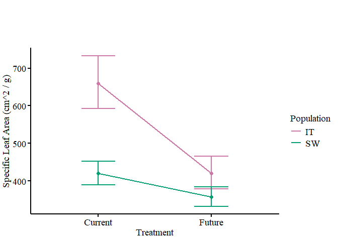

Leaf Dry Matter Content

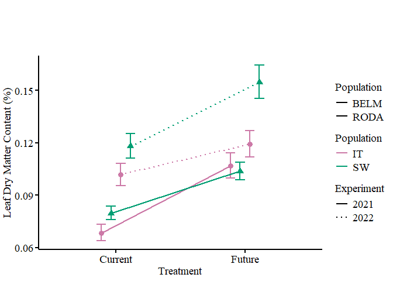

Relative Water Content

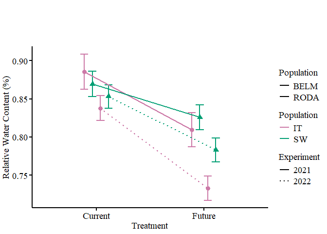

## Leaf Number

LeafNum_4weeks

# Manuscript Figures

creating multipanel figures for the manuscript.

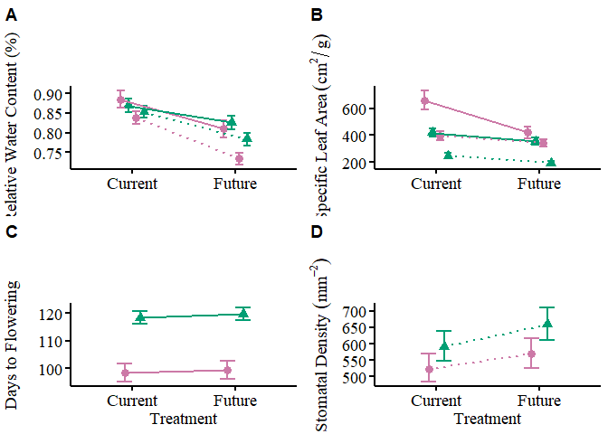

```r
fig1 <- ggarrange(rwc+rremove("xlab"), sla+rremove("xlab"), detf, stoden,
                  labels = c("A", "B", "C", "D"),
                  ncol = 2, nrow = 2,
                  common.legend = TRUE, # created based on the first plot
                  legend = "none",
                  align = "hv"
)
#label.x = c(0, -0.1, -0.1, -0.1, -0.1, 0)
#vjust = 00
fig1
```

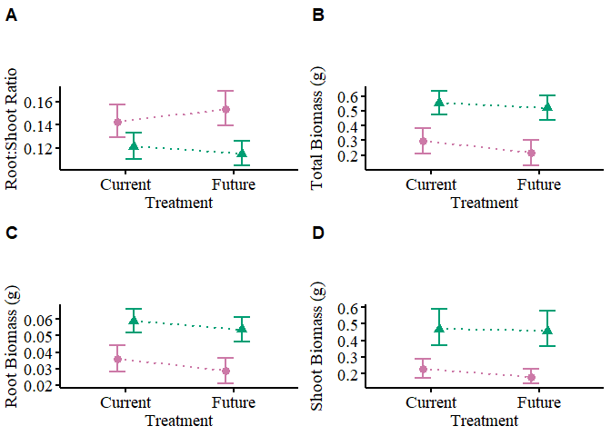

```r
fig2 <- ggarrange(rs, totbio, bg, ros_2022,
                  labels = c("A", "B", "C", "D"),
                  ncol = 2, nrow = 2,
                  common.legend = TRUE,
                  legend = "none",
                  align = "hv")
fig2
```

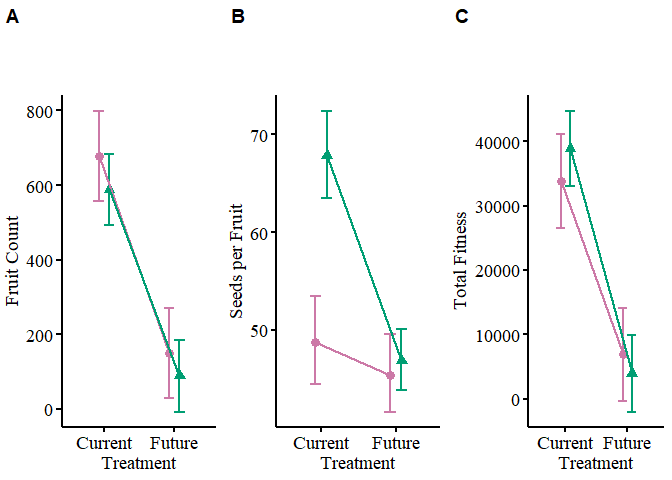

```r
fitness_fig <- ggarrange(fruits, seed_per_fruit, fitness,
                  labels = c("A", "B", "C"),
                  ncol = 3, nrow = 1,
                  common.legend = TRUE,
                  legend = "none",
                  align = "h"
)
fitness_fig
```

# supplemental figures

Figure s1 - single leaf traits

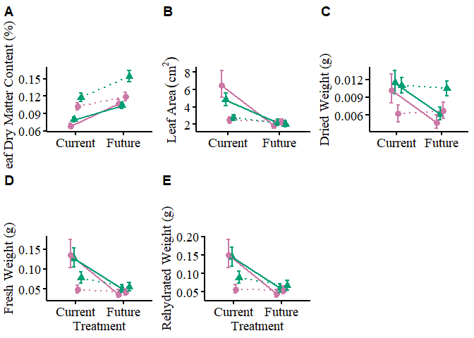

```r
figs1 <- ggarrange(ldmc+rremove("xlab"),area+rremove("xlab"), drywt+rremove("xlab"), freshwt, hydwt,
                  labels = c("A", "B", "C", "D", "E"),
                  ncol = 3, nrow = 2,
                  common.legend = TRUE,
                  legend = "none",
                  align = "h"
                  )
figs1
```

Figure s3 - biomass + fitness

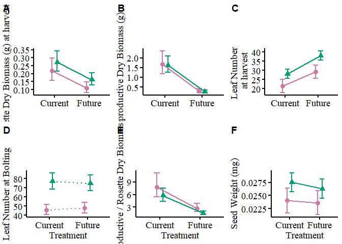

```r
figs3 <- ggarrange(ros_2021+rremove("xlab"), repro+rremove("xlab"), ln_harv+rremove("xlab"),  ln_bolt, rr, seed_wt,
                  labels = c("A", "B", "C", "D", "E", "F"),
                  ncol = 3, nrow = 2,
                  common.legend = TRUE,
                  legend = "none",
                  align = "h"
                  )
figs3
```

Create Legend for main figures

For the traits figure, I need the colors with the shaped points and I need the line types with the years of the experiment

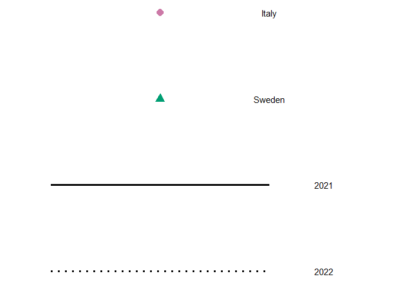

```r
legend_points <- data.frame(xvals = c(1.1, 1.1), yvals = c(4, 3), text = c("Italy", "Sweden"), Pop = as.factor(c("IT", "SW")))
#legend_lines <- c(xvals = c(1, 1), yvals = c(2, 1), text = c("2021", "2022"))

# legend to take up space of a plot
ggplot()+
  geom_point(data = legend_points, aes(x = xvals, y = yvals, col = Pop, shape = Pop), size = 4, show.legend = FALSE)+
  geom_segment(aes(x = 1.09, y = 2, xend = 1.11, yend = 2), linetype = "solid", linewidth = 1.25)+
  geom_segment(aes(x = 1.09, y = 1, xend = 1.11, yend = 1), linetype = "dotted", linewidth = 1.25)+
  geom_text(aes(x = c(1.11, 1.11, 1.115, 1.115), y = c(4, 3, 2, 1), label = c("Italy", "Sweden", "2021", "2022")))+
  scale_color_manual(name = "Population",
                     labels = c("IT", "SW"),
                     values = c("#CC79A7", "#009E73"))+
  xlim(c(1.087, 1.12))+
  theme_void()
```

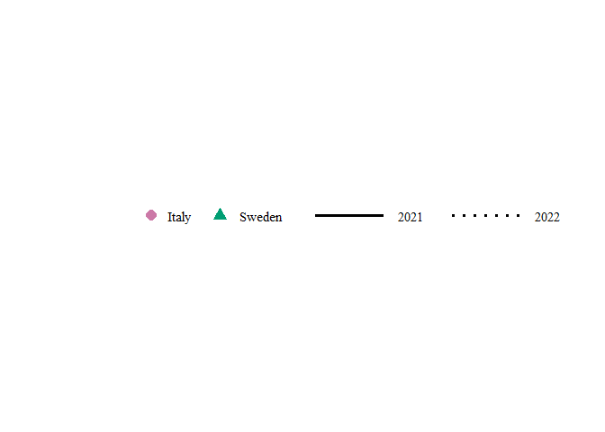

```r
  #theme(plot.margin = margin(t = 0, r = 0.5, b = 0.075, l=0, unit = "in"))

# top legend
legend_points2 <- data.frame(xvals = c(1, 1.5), yvals = c(1, 1), text = c("Italy", "Sweden"), Pop = as.factor(c("IT", "SW")))
legend_fig <- ggplot()+
  geom_point(data = legend_points2, aes(x = xvals, y = yvals, col = Pop, shape = Pop), size = 4, show.legend = FALSE)+
  geom_segment(aes(x = 2.2, y = 1, xend = 2.7, yend = 1), linetype = "solid", linewidth = 1.25)+
  geom_segment(aes(x = 3.2, y = 1, xend = 3.7, yend = 1), linetype = "dotted", linewidth = 1.25)+
  geom_text(aes(x = c(1.2, 1.8, 2.9, 3.9), y = c(1, 1, 1, 1), label = c("Italy", "Sweden", "2021", "2022")), family = "Times")+
  scale_color_manual(name = "Population",
                     labels = c("IT", "SW"),
                     values = c("#CC79A7", "#009E73"))+
  xlim(c(0.087, 4.12))+
  theme_void()
legend_fig
```

##Save figures

```r
# trait figs
ggsave(fig1, filename = "figures/fig1.jpg", width = 6, height = 8, units = "in", dpi = 1000, device = "jpeg")
ggsave(fig2, filename = "figures/fig2.jpg", width = 6, height = 8, units = "in", dpi = 1000)

# fitness fig
ggsave(fitness_fig, filename = "figures/fig3.jpg", width = 9, height = 4, units = "in", dpi = 1000)

# legend_fig
ggsave(legend_fig, filename = "figures/legend_fig3.jpg", width = 6, height = 0.5, units = "in", dpi = 1000)

#figs1
ggsave(figs1, filename = "figures/figs1.jpg", width = 9, height = 8, units = "in", dpi = 600)

#figs2
ggsave(figs3, filename = "figures/figs3.jpg", width = 9, height = 8, units = "in", dpi = 600)
```

figs in vector format; needs the remove package line at the top of the script to actually be saved with times new roman font.

```r
# trait figs
ggsave(fig1, filename = "figures/fig1_times.svg", width = 6, height = 8, units = "in", dpi = 3000, device = "svg")
ggsave(fig2, filename = "figures/fig2_times.svg", width = 6, height = 8, units = "in", dpi = 3000)

# fitness fig
ggsave(fitness_fig, filename = "figures/fig3_times.svg", width = 9, height = 4, units = "in", dpi = 3000)

# legend_fig
ggsave(legend_fig, filename = "figures/legend_fig_times.svg", width = 6, height = 0.5, units = "in", dpi = 3000)

#figs1
ggsave(figs1, filename = "figures/figs1_times.svg", width = 9, height = 8, units = "in", dpi = 600)

#figs2
ggsave(figs3, filename = "figures/figs3_times.svg", width = 9, height = 8, units = "in", dpi = 600)
```